# School adjustment among adolescence…

## Explore the final cluster solution

```r
clustering_results <- res.km5$cluster
table(clustering_results)
```

```
## clustering_results
##    1    2    3    4    5
## 3402 4660 1510 4746 1709
```

Number of observations per cluster in the table above.

```r
dtc %>%
  mutate(Cluster = res.km5$cluster) %>%
  group_by(Cluster) %>%
  summarise_all("mean")
```

```
## # A tibble: 5 x 6
##   Cluster   diff anxiety teacher  peers    depr
##     <int>  <dbl>   <dbl>   <dbl>  <dbl>   <dbl>
## 1       1  0.704  0.601   0.0407  0.427  0.280
## 2       2 -0.328 -0.548   0.170  -0.767 -0.451
## 3       3  0.227 -0.0797 -1.71   -0.774 -0.0297
## 4       4 -0.653 -0.540   0.598   0.807 -0.525
## 5       5  1.11   1.87   -0.693  -0.315  2.16
```

```r
# add the clusters to the data
# dtc$cluster <- as.factor(res.km5$cluster)
# means
# dtc %>% group_by(cluster) %>% summarise_all("mean")
```

**How do the five clusters score on different scales? (means)**

Interpretation: 1: Troubled but connected: moderately high in troubles with learning and mental health, high in peer relations, average on teacher

2: Isolated from peers: low on peer relations. Low in troubles with learning or with mental health. Teacher relations above average.

3: Disconnected: low on peer and teacher relations, above average on learning, average on internalizing

4: Engaged and happy: low in internalizing and difficulties, high in peer and teacher relations

5: Most troubled: high in internalizing and difficulties in learning, low in teacher relations, quite low on peers

```r
# standard deviations
dtc %>%
  mutate(Cluster = res.km5$cluster) %>%
  group_by(Cluster) %>%
  summarise_all("sd")
```

```
## # A tibble: 5 x 6
##   Cluster  diff anxiety teacher peers  depr
##     <int> <dbl>   <dbl>   <dbl> <dbl> <dbl>
## 1       1 0.865   0.799   0.693 0.762 0.696
## 2       2 0.698   0.462   0.596 0.621 0.447
## 3       3 0.966   0.721   0.827 0.939 0.720
## 4       4 0.536   0.443   0.765 0.576 0.350
## 5       5 1.10    0.818   1.04  1.03  0.968
```

Standard deviations in the table above.

```r
# add cluster to the main dataset
dt <- dt %>% mutate(Cluster = res.km5$cluster)
dt <- as.data.table(dt)
# save the dataset with clusters
write.csv(dt, here("data/processed/korona2020a1cl.csv"), row.names = FALSE, fileEncoding = 'UTF-8')
```

# 2 Explore clusters with external variables

Now we profile the clusters with external variables.

## Mean scores

```r
# add cluster to the main dataset
dt <- dt %>% mutate(Cluster = res.km5$cluster)
dt <- as.data.table(dt)
# choose variables for analysis
vars <- c("likesch", "timeusec", "diffsub", "diffsub6", "adhome", "pos", "pos4", "worry", "Cluster")
dta <- dt[,..vars]
dta <- dta %>% na.omit()
dta %>% group_by(Cluster) %>% summarise_all("mean")
```

```
## # A tibble: 5 x 9
##   Cluster likesch timeusec diffsub diffsub6 adhome   pos  pos4 worry
##     <int>   <dbl>    <dbl>   <dbl>    <dbl>  <dbl> <dbl> <dbl> <dbl>
## 1       1    2.33   0.172    1.41     0.900   2.30 0.388 0.394 1.28
## 2       2    2.73  -0.202    0.769    0.549   2.36 0.430 0.374 0.575
## 3       3    2.41  -0.0334   1.14     0.795   2.30 0.388 0.409 0.781
## 4       4    2.89  -0.0258   0.573    0.334   2.33 0.436 0.343 0.708
## 5       5    1.95   0.318    1.81     1.28    2.26 0.351 0.466 1.68
```

```r
# choose variables for analysis
vars <- c("victpre", "vict", "victpre01", "vict01", "bullstopped", "alone79", "peers5", "stress", "Cluster")
dtb <- dt[,..vars]
dtb <- dtb %>% na.omit()
dtb %>% group_by(Cluster) %>% summarise_all("mean")
```

```
## # A tibble: 5 x 9
##   Cluster victpre  vict victpre01  vict01 bullstopped alone79 peers5 stress
##     <int>   <dbl> <dbl>     <dbl>   <dbl>       <dbl>   <dbl>  <dbl>  <dbl>
## 1       1    1.29  1.09    0.0550 0.0165       0.0424    2.59  1.04   1.46
## 2       2    1.23  1.05    0.0432 0.00752      0.0367    2.01  0.994  0.761
## 3       3    1.42  1.17    0.0930 0.0372       0.0651    2.35  1.28   0.912
## 4       4    1.12  1.03    0.0188 0.00422      0.0160    1.87  0.676  0.944
## 5       5    1.75  1.31    0.182  0.0691       0.127     3.57  1.72   1.65
```

## Crosstabulations

```r
CrossTable(dt$Cluster, dt$class, digits = 2, chisq = T, format = "SPSS")
```

```
##
##    Cell Contents
## |-------------------------|
## |                   Count |
## | Chi-square contribution |
## |             Row Percent |
## |          Column Percent |
## |           Total Percent |
## |-------------------------|
##
## Total Observations in Table:  16027
##
##              | dt$class
##   dt$Cluster |        7  |        8  |        9  | Row Total |
## -------------|-----------|-----------|-----------|-----------|
##            1 |     1119  |     1119  |     1164  |     3402  |
##              |     8.48  |     0.03  |    10.90  |           |
##              |    32.89% |    32.89% |    34.22% |    21.23% |
##              |    19.46% |    21.12% |    23.38% |           |
##              |     6.98% |     6.98% |     7.26% |           |
## -------------|-----------|-----------|-----------|-----------|
##            2 |     1766  |     1537  |     1357  |     4660  |
##              |     5.27  |     0.01  |     5.65  |           |
##              |    37.90% |    32.98% |    29.12% |    29.08% |
##              |    30.71% |    29.01% |    27.26% |           |
##              |    11.02% |     9.59% |     8.47% |           |
## -------------|-----------|-----------|-----------|-----------|
##            3 |      461  |      536  |      513  |     1510  |
##              |    12.06  |     2.72  |     4.13  |           |
##              |    30.53% |    35.50% |    33.97% |     9.42% |
##              |     8.02% |    10.12% |    10.31% |           |
##              |     2.88% |     3.34% |     3.20% |           |
## -------------|-----------|-----------|-----------|-----------|
##            4 |     1837  |     1540  |     1369  |     4746  |
##              |    10.54  |     0.53  |     7.49  |           |
##              |    38.71% |    32.45% |    28.85% |    29.61% |
##              |    31.94% |    29.07% |    27.50% |           |
##              |    11.46% |     9.61% |     8.54% |           |
## -------------|-----------|-----------|-----------|-----------|
##            5 |      568  |      566  |      575  |     1709  |
##              |     3.34  |     0.00  |     3.68  |           |
##              |    33.24% |    33.12% |    33.65% |    10.66% |
##              |     9.88% |    10.68% |    11.55% |           |
##              |     3.54% |     3.53% |     3.59% |           |
## -------------|-----------|-----------|-----------|-----------|
## Column Total |     5751  |     5298  |     4978  |    16027  |
##              |    35.88% |    33.06% |    31.06% |           |
## -------------|-----------|-----------|-----------|-----------|
##
##
## Statistics for All Table Factors
##
##
## Pearson's Chi-squared test
## ------------------------------------------------------------
## Chi^2 =  74.82252     d.f. =  8     p =  5.353265e-13
##
##
##
##        Minimum expected frequency: 469.0073
```

```r
CrossTable(dt$Cluster, dt$timeuse, digits = 2, chisq = T, format = "SPSS")
```

```
##
##    Cell Contents
## |-------------------------|
## |                   Count |
## | Chi-square contribution |
## |             Row Percent |
## |          Column Percent |
## |           Total Percent |
## |-------------------------|
##
## Total Observations in Table:  16027
##
##              | dt$timeuse
##   dt$Cluster |        1  |        2  |        3  |        4  |        5  |        6  |        7  | Row Total |
## -------------|-----------|-----------|-----------|-----------|-----------|-----------|-----------|-----------|
##            1 |       53  |      204  |      686  |     1050  |      926  |      392  |       91  |     3402  |
##              |     4.33  |     2.31  |    18.04  |     3.72  |    10.00  |    48.59  |     4.55  |           |
##              |     1.56% |     6.00% |    20.16% |    30.86% |    27.22% |    11.52% |     2.67% |    21.23% |
##              |    15.96% |    19.08% |    18.05% |    20.00% |    23.55% |    30.13% |    26.53% |           |
##              |     0.33% |     1.27% |     4.28% |     6.55% |     5.78% |     2.45% |     0.57% |           |
## -------------|-----------|-----------|-----------|-----------|-----------|-----------|-----------|-----------|
##            2 |      112  |      380  |     1298  |     1557  |     1044  |      228  |       41  |     4660  |
##              |     2.48  |    15.40  |    33.75  |     0.61  |     8.62  |    59.70  |    34.59  |           |
##              |     2.40% |     8.15% |    27.85% |    33.41% |    22.40% |     4.89% |     0.88% |    29.08% |
##              |    33.73% |    35.55% |    34.16% |    29.66% |    26.55% |    17.52% |    11.95% |           |
##              |     0.70% |     2.37% |     8.10% |     9.71% |     6.51% |     1.42% |     0.26% |           |
## -------------|-----------|-----------|-----------|-----------|-----------|-----------|-----------|-----------|
##            3 |       51  |      124  |      350  |      456  |      342  |      145  |       42  |     1510  |
##              |    12.43  |     5.38  |     0.18  |     3.02  |     2.19  |     4.10  |     2.90  |           |
##              |     3.38% |     8.21% |    23.18% |    30.20% |    22.65% |     9.60% |     2.78% |     9.42% |
##              |    15.36% |    11.60% |     9.21% |     8.69% |     8.70% |    11.15% |    12.24% |           |
##              |     0.32% |     0.77% |     2.18% |     2.85% |     2.13% |     0.90% |     0.26% |           |
## -------------|-----------|-----------|-----------|-----------|-----------|-----------|-----------|-----------|
##            4 |       46  |      255  |     1151  |     1794  |     1204  |      256  |       40  |     4746  |
##              |    27.84  |    11.97  |     0.59  |    36.85  |     1.35  |    43.37  |    37.32  |           |
##              |     0.97% |     5.37% |    24.25% |    37.80% |    25.37% |     5.39% |     0.84% |    29.61% |
##              |    13.86% |    23.85% |    30.29% |    34.17% |    30.62% |    19.68% |    11.66% |           |
##              |     0.29% |     1.59% |     7.18% |    11.19% |     7.51% |     1.60% |     0.25% |           |
## -------------|-----------|-----------|-----------|-----------|-----------|-----------|-----------|-----------|
##            5 |       70  |      106  |      315  |      393  |      416  |      280  |      129  |     1709  |
##              |    33.81  |     0.56  |    20.08  |    49.71  |     0.03  |   143.86  |   233.56  |           |
##              |     4.10% |     6.20% |    18.43% |    23.00% |    24.34% |    16.38% |     7.55% |    10.66% |
##              |    21.08% |     9.92% |     8.29% |     7.49% |    10.58% |    21.52% |    37.61% |           |
##              |     0.44% |     0.66% |     1.97% |     2.45% |     2.60% |     1.75% |     0.80% |           |
## -------------|-----------|-----------|-----------|-----------|-----------|-----------|-----------|-----------|
## Column Total |      332  |     1069  |     3800  |     5250  |     3932  |     1301  |      343  |    16027  |
##              |     2.07% |     6.67% |    23.71% |    32.76% |    24.53% |     8.12% |     2.14% |           |
## -------------|-----------|-----------|-----------|-----------|-----------|-----------|-----------|-----------|
##
##
## Statistics for All Table Factors
##
##
## Pearson's Chi-squared test
## ------------------------------------------------------------
## Chi^2 =  917.7795     d.f. =  24     p =  2.482315e-178
##
##
##
##        Minimum expected frequency: 31.27972
```

```r
CrossTable(dt$Cluster, dt$likesch01, digits = 2, chisq = T, format = "SPSS")
```

```
##
##    Cell Contents
## |-------------------------|
## |                   Count |
## | Chi-square contribution |
## |             Row Percent |
## |          Column Percent |
## |           Total Percent |
## |-------------------------|
##
## Total Observations in Table:  16027
##
##              | dt$likesch01
##   dt$Cluster |        0  |        1  | Row Total |
## -------------|-----------|-----------|-----------|
##            1 |     2080  |     1322  |     3402  |
##              |   195.72  |   160.41  |           |
##              |    61.14% |    38.86% |    21.23% |
##              |    28.81% |    15.01% |           |
##              |    12.98% |     8.25% |           |
## -------------|-----------|-----------|-----------|
##            2 |     1726  |     2934  |     4660  |
##              |    66.28  |    54.32  |           |
##              |    37.04% |    62.96% |    29.08% |
##              |    23.91% |    33.31% |           |
##              |    10.77% |    18.31% |           |
## -------------|-----------|-----------|-----------|
##            3 |      855  |      655  |     1510  |
##              |    44.95  |    36.84  |           |
##              |    56.62% |    43.38% |     9.42% |
##              |    11.84% |     7.44% |           |
##              |     5.33% |     4.09% |           |
## -------------|-----------|-----------|-----------|
##            4 |     1242  |     3504  |     4746  |
##              |   375.32  |   307.61  |           |
##              |    26.17% |    73.83% |    29.61% |
##              |    17.20% |    39.78% |           |
##              |     7.75% |    21.86% |           |
## -------------|-----------|-----------|-----------|
##            5 |     1316  |      393  |     1709  |
##              |   387.59  |   317.66  |           |
##              |    77.00% |    23.00% |    10.66% |
##              |    18.23% |     4.46% |           |
##              |     8.21% |     2.45% |           |
## -------------|-----------|-----------|-----------|
## Column Total |     7219  |     8808  |    16027  |
##              |    45.04% |    54.96% |           |
## -------------|-----------|-----------|-----------|
##
##
## Statistics for All Table Factors
##
##
## Pearson's Chi-squared test
## ------------------------------------------------------------
## Chi^2 =  1946.713     d.f. =  4     p =  0
##
##
##
##        Minimum expected frequency: 680.1454
```

```r
CrossTable(dt$Cluster, dt$morearg01, digits = 2, chisq = T, format = "SPSS")
```

```
##
##    Cell Contents
## |-------------------------|
## |                   Count |
## | Chi-square contribution |
## |             Row Percent |
## |          Column Percent |
## |           Total Percent |
## |-------------------------|
##
## Total Observations in Table:  15714
##
##              | dt$morearg01
##   dt$Cluster |        0  |        1  | Row Total |
## -------------|-----------|-----------|-----------|
##            1 |     2704  |      636  |     3340  |
##              |    14.50  |    97.95  |           |
##              |    80.96% |    19.04% |    21.25% |
##              |    19.75% |    31.39% |           |
##              |    17.21% |     4.05% |           |
## -------------|-----------|-----------|-----------|
##            2 |     4256  |      305  |     4561  |
##              |    20.17  |   136.24  |           |
##              |    93.31% |     6.69% |    29.03% |
##              |    31.09% |    15.05% |           |
##              |    27.08% |     1.94% |           |
## -------------|-----------|-----------|-----------|
##            3 |     1282  |      189  |     1471  |
##              |     0.00  |     0.00  |           |
##              |    87.15% |    12.85% |     9.36% |
##              |     9.37% |     9.33% |           |
##              |     8.16% |     1.20% |           |
## -------------|-----------|-----------|-----------|
##            4 |     4335  |      328  |     4663  |
##              |    18.38  |   124.15  |           |
##              |    92.97% |     7.03% |    29.67% |
##              |    31.67% |    16.19% |           |
##              |    27.59% |     2.09% |           |
## -------------|-----------|-----------|-----------|
##            5 |     1111  |      568  |     1679  |
##              |    84.49  |   570.84  |           |
##              |    66.17% |    33.83% |    10.68% |
##              |     8.12% |    28.04% |           |
##              |     7.07% |     3.61% |           |
## -------------|-----------|-----------|-----------|
## Column Total |    13688  |     2026  |    15714  |
##              |    87.11% |    12.89% |           |
## -------------|-----------|-----------|-----------|
##
##
## Statistics for All Table Factors
##
##
## Pearson's Chi-squared test
## ------------------------------------------------------------
## Chi^2 =  1066.71     d.f. =  4     p =  1.243819e-229
##
##
##
##        Minimum expected frequency: 189.6555
```

```r
CrossTable(dt$Cluster, dt$noteacher01, digits = 2, chisq = T, format = "SPSS")
```

```
##
##    Cell Contents
## |-------------------------|
## |                   Count |
## | Chi-square contribution |
## |             Row Percent |
## |          Column Percent |
## |           Total Percent |
## |-------------------------|
##
## Total Observations in Table:  16027
##
##              | dt$noteacher01
##   dt$Cluster |        0  |        1  | Row Total |
## -------------|-----------|-----------|-----------|
##            1 |     2981  |      421  |     3402  |
##              |     5.17  |    27.23  |           |
##              |    87.62% |    12.38% |    21.23% |
##              |    22.13% |    16.47% |           |
##              |    18.60% |     2.63% |           |
## -------------|-----------|-----------|-----------|
##            2 |     4303  |      357  |     4660  |
##              |    38.08  |   200.67  |           |
##              |    92.34% |     7.66% |    29.08% |
##              |    31.94% |    13.97% |           |
##              |    26.85% |     2.23% |           |
## -------------|-----------|-----------|-----------|
##            3 |      527  |      983  |     1510  |
##              |   434.01  |  2287.38  |           |
##              |    34.90% |    65.10% |     9.42% |
##              |     3.91% |    38.46% |           |
##              |     3.29% |     6.13% |           |
## -------------|-----------|-----------|-----------|
##            4 |     4552  |      194  |     4746  |
##              |    79.43  |   418.62  |           |
##              |    95.91% |     4.09% |    29.61% |
##              |    33.79% |     7.59% |           |
##              |    28.40% |     1.21% |           |
## -------------|-----------|-----------|-----------|
##            5 |     1108  |      601  |     1709  |
##              |    75.10  |   395.80  |           |
##              |    64.83% |    35.17% |    10.66% |
##              |     8.23% |    23.51% |           |
##              |     6.91% |     3.75% |           |
## -------------|-----------|-----------|-----------|
## Column Total |    13471  |     2556  |    16027  |
##              |    84.05% |    15.95% |           |
## -------------|-----------|-----------|-----------|
##
##
## Statistics for All Table Factors
##
##
## Pearson's Chi-squared test
## ------------------------------------------------------------
## Chi^2 =  3961.487     d.f. =  4     p =  0
##
##
##
##        Minimum expected frequency: 240.8161
```

```r
CrossTable(dt$Cluster, dt$suppneed01, digits = 2, chisq = T, format = "SPSS")
```

```
##
##    Cell Contents
## |-------------------------|
## |                   Count |
## | Chi-square contribution |
## |             Row Percent |
## |          Column Percent |
## |           Total Percent |
## |-------------------------|
##
## Total Observations in Table:  16027
##
##              | dt$suppneed01
##   dt$Cluster |        0  |        1  | Row Total |
## -------------|-----------|-----------|-----------|
##            1 |      829  |     2573  |     3402  |
##              |   340.22  |   287.03  |           |
##              |    24.37% |    75.63% |    21.23% |
##              |    11.30% |    29.60% |           |
##              |     5.17% |    16.05% |           |
## -------------|-----------|-----------|-----------|
##            2 |     2923  |     1737  |     4660  |
##              |   293.09  |   247.27  |           |
##              |    62.73% |    37.27% |    29.08% |
##              |    39.86% |    19.98% |           |
##              |    18.24% |    10.84% |           |
## -------------|-----------|-----------|-----------|
##            3 |      725  |      785  |     1510  |
##              |     1.67  |     1.41  |           |
##              |    48.01% |    51.99% |     9.42% |
##              |     9.89% |     9.03% |           |
##              |     4.52% |     4.90% |           |
## -------------|-----------|-----------|-----------|
##            4 |     2656  |     2090  |     4746  |
##              |   107.96  |    91.08  |           |
##              |    55.96% |    44.04% |    29.61% |
##              |    36.21% |    24.04% |           |
##              |    16.57% |    13.04% |           |
## -------------|-----------|-----------|-----------|
##            5 |      201  |     1508  |     1709  |
##              |   431.70  |   364.21  |           |
##              |    11.76% |    88.24% |    10.66% |
##              |     2.74% |    17.35% |           |
##              |     1.25% |     9.41% |           |
## -------------|-----------|-----------|-----------|
## Column Total |     7334  |     8693  |    16027  |
##              |    45.76% |    54.24% |           |
## -------------|-----------|-----------|-----------|
##
##
## Statistics for All Table Factors
##
##
## Pearson's Chi-squared test
## ------------------------------------------------------------
## Chi^2 =  2165.669     d.f. =  4     p =  0
##
##
##
##        Minimum expected frequency: 690.9802
```

```r
CrossTable(dt$Cluster, dt$worry901, digits = 2, chisq = T, format = "SPSS")
```

```
##
##    Cell Contents
## |-------------------------|
## |                   Count |
## | Chi-square contribution |
## |             Row Percent |
## |          Column Percent |
## |           Total Percent |
## |-------------------------|
##
## Total Observations in Table:  15963
##
##              | dt$worry901
##   dt$Cluster |        0  |        1  | Row Total |
## -------------|-----------|-----------|-----------|
##            1 |     2408  |      978  |     3386  |
##              |    38.62  |   161.62  |           |
##              |    71.12% |    28.88% |    21.21% |
##              |    18.69% |    31.76% |           |
##              |    15.08% |     6.13% |           |
## -------------|-----------|-----------|-----------|
##            2 |     3937  |      712  |     4649  |
##              |     9.09  |    38.05  |           |
##              |    84.68% |    15.32% |    29.12% |
##              |    30.56% |    23.12% |           |
##              |    24.66% |     4.46% |           |
## -------------|-----------|-----------|-----------|
##            3 |     1195  |      304  |     1499  |
##              |     0.18  |     0.76  |           |
##              |    79.72% |    20.28% |     9.39% |
##              |     9.28% |     9.87% |           |
##              |     7.49% |     1.90% |           |
## -------------|-----------|-----------|-----------|
##            4 |     3984  |      747  |     4731  |
##              |     7.18  |    30.03  |           |
##              |    84.21% |    15.79% |    29.64% |
##              |    30.92% |    24.26% |           |
##              |    24.96% |     4.68% |           |
## -------------|-----------|-----------|-----------|
##            5 |     1360  |      338  |     1698  |
##              |     0.08  |     0.34  |           |
##              |    80.09% |    19.91% |    10.64% |
##              |    10.56% |    10.98% |           |
##              |     8.52% |     2.12% |           |
## -------------|-----------|-----------|-----------|
## Column Total |    12884  |     3079  |    15963  |
##              |    80.71% |    19.29% |           |
## -------------|-----------|-----------|-----------|
##
##
## Statistics for All Table Factors
##
##
## Pearson's Chi-squared test
## ------------------------------------------------------------
## Chi^2 =  285.9585     d.f. =  4     p =  1.156671e-60
##
##
##
##        Minimum expected frequency: 289.1324
```

```r
CrossTable(dt$Cluster, dt$nofriend01, digits = 2, chisq = T, format = "SPSS")
```

```
##
##    Cell Contents
## |-------------------------|
## |                   Count |
## | Chi-square contribution |
## |             Row Percent |
## |          Column Percent |
## |           Total Percent |
## |-------------------------|
##
## Total Observations in Table:  16027
##
##              | dt$nofriend01
##   dt$Cluster |        0  |        1  | Row Total |
## -------------|-----------|-----------|-----------|
##            1 |     3156  |      246  |     3402  |
##              |     3.69  |    32.00  |           |
##              |    92.77% |     7.23% |    21.23% |
##              |    21.97% |    14.83% |           |
##              |    19.69% |     1.53% |           |
## -------------|-----------|-----------|-----------|
##            2 |     3998  |      662  |     4660  |
##              |     7.72  |    66.89  |           |
##              |    85.79% |    14.21% |    29.08% |
##              |    27.83% |    39.90% |           |
##              |    24.95% |     4.13% |           |
## -------------|-----------|-----------|-----------|
##            3 |     1228  |      282  |     1510  |
##              |    11.67  |   101.08  |           |
##              |    81.32% |    18.68% |     9.42% |
##              |     8.55% |    17.00% |           |
##              |     7.66% |     1.76% |           |
## -------------|-----------|-----------|-----------|
##            4 |     4604  |      142  |     4746  |
##              |    28.67  |   248.32  |           |
##              |    97.01% |     2.99% |    29.61% |
##              |    32.04% |     8.56% |           |
##              |    28.73% |     0.89% |           |
## -------------|-----------|-----------|-----------|
##            5 |     1382  |      327  |     1709  |
##              |    14.70  |   127.35  |           |
##              |    80.87% |    19.13% |    10.66% |
##              |     9.62% |    19.71% |           |
##              |     8.62% |     2.04% |           |
## -------------|-----------|-----------|-----------|
## Column Total |    14368  |     1659  |    16027  |
##              |    89.65% |    10.35% |           |
## -------------|-----------|-----------|-----------|
##
##
## Statistics for All Table Factors
##
##
## Pearson's Chi-squared test
## ------------------------------------------------------------
## Chi^2 =  642.1056     d.f. =  4     p =  1.192515e-137
##
##
##
##        Minimum expected frequency: 156.3044
```

```r
CrossTable(dt$Cluster, dt$pos1, digits = 2, chisq = T, format = "SPSS")
```

```
##
##    Cell Contents
## |-------------------------|
## |                   Count |
## | Chi-square contribution |
## |             Row Percent |
## |          Column Percent |
## |           Total Percent |
## |-------------------------|
##
## Total Observations in Table:  16027
##
##              | dt$pos1
##   dt$Cluster |        0  |        1  | Row Total |
## -------------|-----------|-----------|-----------|
##            1 |     1425  |     1977  |     3402  |
##              |    79.22  |    39.21  |           |
##              |    41.89% |    58.11% |    21.23% |
##              |    26.86% |    18.44% |           |
##              |     8.89% |    12.34% |           |
## -------------|-----------|-----------|-----------|
##            2 |     1179  |     3481  |     4660  |
##              |    85.77  |    42.45  |           |
##              |    25.30% |    74.70% |    29.08% |
##              |    22.22% |    32.47% |           |
##              |     7.36% |    21.72% |           |
## -------------|-----------|-----------|-----------|
##            3 |      529  |      981  |     1510  |
##              |     1.69  |     0.84  |           |
##              |    35.03% |    64.97% |     9.42% |
##              |     9.97% |     9.15% |           |
##              |     3.30% |     6.12% |           |
## -------------|-----------|-----------|-----------|
##            4 |     1246  |     3500  |     4746  |
##              |    67.32  |    33.32  |           |
##              |    26.25% |    73.75% |    29.61% |
##              |    23.48% |    32.65% |           |
##              |     7.77% |    21.84% |           |
## -------------|-----------|-----------|-----------|
##            5 |      927  |      782  |     1709  |
##              |   230.60  |   114.13  |           |
##              |    54.24% |    45.76% |    10.66% |
##              |    17.47% |     7.29% |           |
##              |     5.78% |     4.88% |           |
## -------------|-----------|-----------|-----------|
## Column Total |     5306  |    10721  |    16027  |
##              |    33.11% |    66.89% |           |
## -------------|-----------|-----------|-----------|
##
##
## Statistics for All Table Factors
##
##
## Pearson's Chi-squared test
## ------------------------------------------------------------
## Chi^2 =  694.5563     d.f. =  4     p =  5.259595e-149
##
##
##
##        Minimum expected frequency: 499.9102
```

```r
CrossTable(dt$Cluster, dt$pos6, digits = 2, chisq = T, format = "SPSS")
```

```
##
##    Cell Contents
## |-------------------------|
## |                   Count |
## | Chi-square contribution |
## |             Row Percent |
## |          Column Percent |
## |           Total Percent |
## |-------------------------|
##
## Total Observations in Table:  16027
##
##              | dt$pos6
##   dt$Cluster |        0  |        1  | Row Total |
## -------------|-----------|-----------|-----------|
##            1 |     3041  |      361  |     3402  |
##              |     0.33  |     2.53  |           |
##              |    89.39% |    10.61% |    21.23% |
##              |    21.45% |    19.52% |           |
##              |    18.97% |     2.25% |           |
## -------------|-----------|-----------|-----------|
##            2 |     4125  |      535  |     4660  |
##              |     0.00  |     0.01  |           |
##              |    88.52% |    11.48% |    29.08% |
##              |    29.09% |    28.93% |           |
##              |    25.74% |     3.34% |           |
## -------------|-----------|-----------|-----------|
##            3 |     1361  |      149  |     1510  |
##              |     0.48  |     3.65  |           |
##              |    90.13% |     9.87% |     9.42% |
##              |     9.60% |     8.06% |           |
##              |     8.49% |     0.93% |           |
## -------------|-----------|-----------|-----------|
##            4 |     4084  |      662  |     4746  |
##              |     3.12  |    23.93  |           |
##              |    86.05% |    13.95% |    29.61% |
##              |    28.81% |    35.80% |           |
##              |    25.48% |     4.13% |           |
## -------------|-----------|-----------|-----------|
##            5 |     1567  |      142  |     1709  |
##              |     2.01  |    15.43  |           |
##              |    91.69% |     8.31% |    10.66% |
##              |    11.05% |     7.68% |           |
##              |     9.78% |     0.89% |           |
## -------------|-----------|-----------|-----------|
## Column Total |    14178  |     1849  |    16027  |
##              |    88.46% |    11.54% |           |
## -------------|-----------|-----------|-----------|
##
##
## Statistics for All Table Factors
##
##
## Pearson's Chi-squared test
## ------------------------------------------------------------
## Chi^2 =  51.48802     d.f. =  4     p =  1.764999e-10
##
##
##
##        Minimum expected frequency: 174.2054
```

```r
CrossTable(dt$Cluster, dt$posno, digits = 2, chisq = T, format = "SPSS")
```

```
##
##    Cell Contents
## |-------------------------|
## |                   Count |
## | Chi-square contribution |
## |             Row Percent |
## |          Column Percent |
## |           Total Percent |
## |-------------------------|
##
## Total Observations in Table:  16027
##
##              | dt$posno
##   dt$Cluster |        0  |        1  | Row Total |
## -------------|-----------|-----------|-----------|
##            1 |     3043  |      359  |     3402  |
##              |     1.14  |    11.82  |           |
##              |    89.45% |    10.55% |    21.23% |
##              |    20.82% |    25.44% |           |
##              |    18.99% |     2.24% |           |
## -------------|-----------|-----------|-----------|
##            2 |     4384  |      276  |     4660  |
##              |     4.24  |    43.94  |           |
##              |    94.08% |     5.92% |    29.08% |
##              |    29.99% |    19.56% |           |
##              |    27.35% |     1.72% |           |
## -------------|-----------|-----------|-----------|
##            3 |     1287  |      223  |     1510  |
##              |     5.89  |    61.01  |           |
##              |    85.23% |    14.77% |     9.42% |
##              |     8.81% |    15.80% |           |
##              |     8.03% |     1.39% |           |
## -------------|-----------|-----------|-----------|
##            4 |     4590  |      156  |     4746  |
##              |    15.84  |   164.08  |           |
##              |    96.71% |     3.29% |    29.61% |
##              |    31.40% |    11.06% |           |
##              |    28.64% |     0.97% |           |
## -------------|-----------|-----------|-----------|
##            5 |     1312  |      397  |     1709  |
##              |    39.00  |   403.98  |           |
##              |    76.77% |    23.23% |    10.66% |
##              |     8.98% |    28.14% |           |
##              |     8.19% |     2.48% |           |
## -------------|-----------|-----------|-----------|
## Column Total |    14616  |     1411  |    16027  |
##              |    91.20% |     8.80% |           |
## -------------|-----------|-----------|-----------|
##
##
## Statistics for All Table Factors
##
##
## Pearson's Chi-squared test
## ------------------------------------------------------------
## Chi^2 =  750.9393     d.f. =  4     p =  3.245918e-161
##
##
##
##        Minimum expected frequency: 132.9388
```

```r
CrossTable(dt$Cluster, dt$supped1, digits = 2, chisq = T, format = "SPSS")
```

```
##
##    Cell Contents
## |-------------------------|
## |                   Count |
## | Chi-square contribution |
## |             Row Percent |
## |          Column Percent |
## |           Total Percent |
## |-------------------------|
##
## Total Observations in Table:  15496
##
##              | dt$supped1
##   dt$Cluster |        0  |        1  | Row Total |
## -------------|-----------|-----------|-----------|
##            1 |      578  |     2773  |     3351  |
##              |    13.92  |     3.51  |           |
##              |    17.25% |    82.75% |    21.62% |
##              |    18.52% |    22.41% |           |
##              |     3.73% |    17.89% |           |
## -------------|-----------|-----------|-----------|
##            2 |      810  |     3652  |     4462  |
##              |     8.75  |     2.21  |           |
##              |    18.15% |    81.85% |    28.79% |
##              |    25.95% |    29.51% |           |
##              |     5.23% |    23.57% |           |
## -------------|-----------|-----------|-----------|
##            3 |      635  |      832  |     1467  |
##              |   390.18  |    98.40  |           |
##              |    43.29% |    56.71% |     9.47% |
##              |    20.35% |     6.72% |           |
##              |     4.10% |     5.37% |           |
## -------------|-----------|-----------|-----------|
##            4 |      482  |     4052  |     4534  |
##              |   203.59  |    51.35  |           |
##              |    10.63% |    89.37% |    29.26% |
##              |    15.44% |    32.74% |           |
##              |     3.11% |    26.15% |           |
## -------------|-----------|-----------|-----------|
##            5 |      616  |     1066  |     1682  |
##              |   226.88  |    57.22  |           |
##              |    36.62% |    63.38% |    10.85% |
##              |    19.74% |     8.61% |           |
##              |     3.98% |     6.88% |           |
## -------------|-----------|-----------|-----------|
## Column Total |     3121  |    12375  |    15496  |
##              |    20.14% |    79.86% |           |
## -------------|-----------|-----------|-----------|
##
##
## Statistics for All Table Factors
##
##
## Pearson's Chi-squared test
## ------------------------------------------------------------
## Chi^2 =  1056.005     d.f. =  4     p =  2.600101e-227
##
##
##
##        Minimum expected frequency: 295.4638
```

```r
CrossTable(dt$Cluster, dt$supped2, digits = 2, chisq = T, format = "SPSS")
```

```
##
##    Cell Contents
## |-------------------------|
## |                   Count |
## | Chi-square contribution |
## |             Row Percent |
## |          Column Percent |
## |           Total Percent |
## |-------------------------|
##
## Total Observations in Table:  15531
##
##              | dt$supped2
##   dt$Cluster |        0  |        1  | Row Total |
## -------------|-----------|-----------|-----------|
##            1 |      527  |     2835  |     3362  |
##              |     2.09  |     0.36  |           |
##              |    15.68% |    84.32% |    21.65% |
##              |    23.05% |    21.40% |           |
##              |     3.39% |    18.25% |           |
## -------------|-----------|-----------|-----------|
##            2 |      515  |     3967  |     4482  |
##              |    31.74  |     5.48  |           |
##              |    11.49% |    88.51% |    28.86% |
##              |    22.53% |    29.95% |           |
##              |     3.32% |    25.54% |           |
## -------------|-----------|-----------|-----------|
##            3 |      371  |     1096  |     1467  |
##              |   111.37  |    19.22  |           |
##              |    25.29% |    74.71% |     9.45% |
##              |    16.23% |     8.27% |           |
##              |     2.39% |     7.06% |           |
## -------------|-----------|-----------|-----------|
##            4 |      308  |     4230  |     4538  |
##              |   193.97  |    33.48  |           |
##              |     6.79% |    93.21% |    29.22% |
##              |    13.47% |    31.94% |           |
##              |     1.98% |    27.24% |           |
## -------------|-----------|-----------|-----------|
##            5 |      565  |     1117  |     1682  |
##              |   406.99  |    70.24  |           |
##              |    33.59% |    66.41% |    10.83% |
##              |    24.72% |     8.43% |           |
##              |     3.64% |     7.19% |           |
## -------------|-----------|-----------|-----------|
## Column Total |     2286  |    13245  |    15531  |
##              |    14.72% |    85.28% |           |
## -------------|-----------|-----------|-----------|
##
##
## Statistics for All Table Factors
##
##
## Pearson's Chi-squared test
## ------------------------------------------------------------
## Chi^2 =  874.9414     d.f. =  4     p =  4.475334e-188
##
##
##
##        Minimum expected frequency: 215.927
```

```r
dt[, timeusel := ifelse(timeuse > 4, 'yli 5h', 'alle 5h')]
freq(dt$timeusel)
```

```
##                   Freq    Perc
##  Value   alle 5h 10451  65.21%
##          yli 5h   5576  34.79%
##          Total   16027 100.00%
##  Missing NA          0   0.00%
```

```r
CrossTable(dt$Cluster, dt$timeusel, digits = 2, chisq = T, format = "SPSS")
```

```
##
##    Cell Contents
## |-------------------------|
## |                   Count |
## | Chi-square contribution |
## |             Row Percent |
## |          Column Percent |
## |           Total Percent |
## |-------------------------|
##
## Total Observations in Table:  16027
##
##              | dt$timeusel
##   dt$Cluster |  alle 5h  |   yli 5h  | Row Total |
## -------------|-----------|-----------|-----------|
##            1 |     1993  |     1409  |     3402  |
##              |    22.90  |    42.92  |           |
##              |    58.58% |    41.42% |    21.23% |
##              |    19.07% |    25.27% |           |
##              |    12.44% |     8.79% |           |
## -------------|-----------|-----------|-----------|
##            2 |     3347  |     1313  |     4660  |
##              |    31.27  |    58.62  |           |
##              |    71.82% |    28.18% |    29.08% |
##              |    32.03% |    23.55% |           |
##              |    20.88% |     8.19% |           |
## -------------|-----------|-----------|-----------|
##            3 |      981  |      529  |     1510  |
##              |     0.01  |     0.03  |           |
##              |    64.97% |    35.03% |     9.42% |
##              |     9.39% |     9.49% |           |
##              |     6.12% |     3.30% |           |
## -------------|-----------|-----------|-----------|
##            4 |     3246  |     1500  |     4746  |
##              |     7.39  |    13.84  |           |
##              |    68.39% |    31.61% |    29.61% |
##              |    31.06% |    26.90% |           |
##              |    20.25% |     9.36% |           |
## -------------|-----------|-----------|-----------|
##            5 |      884  |      825  |     1709  |
##              |    47.64  |    89.29  |           |
##              |    51.73% |    48.27% |    10.66% |
##              |     8.46% |    14.80% |           |
##              |     5.52% |     5.15% |           |
## -------------|-----------|-----------|-----------|
## Column Total |    10451  |     5576  |    16027  |
##              |    65.21% |    34.79% |           |
## -------------|-----------|-----------|-----------|
##
##
## Statistics for All Table Factors
##
##
## Pearson's Chi-squared test
## ------------------------------------------------------------
## Chi^2 =  313.9198     d.f. =  4     p =  1.075774e-66
##
##
##
##        Minimum expected frequency: 525.3485
```

```r
dt[, timeusecl := ifelse(timeusec > 0, 'enemmän', 'vähemmän')]
freq(dt$timeusecl)
```

```
##                    Freq    Perc
##  Value   enemmän   7530  46.98%
##          vähemmän  8497  53.02%
##          Total    16027 100.00%
##  Missing NA           0   0.00%
```

```r
CrossTable(dt$Cluster, dt$timeusecl, digits = 2, chisq = T, format = "SPSS")
```

```
##
##    Cell Contents
## |-------------------------|
## |                   Count |
## | Chi-square contribution |
## |             Row Percent |
## |          Column Percent |
## |           Total Percent |
## |-------------------------|
##
## Total Observations in Table:  16027
##
##              | dt$timeusecl
##   dt$Cluster |  enemmän  | vähemmän  | Row Total |
## -------------|-----------|-----------|-----------|
##            1 |     1769  |     1633  |     3402  |
##              |    18.22  |    16.14  |           |
##              |    52.00% |    48.00% |    21.23% |
##              |    23.49% |    19.22% |           |
##              |    11.04% |    10.19% |           |
## -------------|-----------|-----------|-----------|
##            2 |     1896  |     2764  |     4660  |
##              |    39.32  |    34.85  |           |
##              |    40.69% |    59.31% |    29.08% |
##              |    25.18% |    32.53% |           |
##              |    11.83% |    17.25% |           |
## -------------|-----------|-----------|-----------|
##            3 |      674  |      836  |     1510  |
##              |     1.77  |     1.57  |           |
##              |    44.64% |    55.36% |     9.42% |
##              |     8.95% |     9.84% |           |
##              |     4.21% |     5.22% |           |
## -------------|-----------|-----------|-----------|
##            4 |     2214  |     2532  |     4746  |
##              |     0.11  |     0.10  |           |
##              |    46.65% |    53.35% |    29.61% |
##              |    29.40% |    29.80% |           |
##              |    13.81% |    15.80% |           |
## -------------|-----------|-----------|-----------|
##            5 |      977  |      732  |     1709  |
##              |    37.73  |    33.44  |           |
##              |    57.17% |    42.83% |    10.66% |
##              |    12.97% |     8.61% |           |
##              |     6.10% |     4.57% |           |
## -------------|-----------|-----------|-----------|
## Column Total |     7530  |     8497  |    16027  |
##              |    46.98% |    53.02% |           |
## -------------|-----------|-----------|-----------|
##
##
## Statistics for All Table Factors
##
##
## Pearson's Chi-squared test
## ------------------------------------------------------------
## Chi^2 =  183.2485     d.f. =  4     p =  1.495625e-38
##
##
##
##        Minimum expected frequency: 709.4466
```

## Kruskal and Wilcox tests

```r
dt %>% select(one_of(c('class', 'diff', 'peers', 'teacher', 'anxiety', 'depr', 'timeuse'))) %>% group_by(class) %>% summarise_all("mean")
```

```
## # A tibble: 3 x 7
##   class  diff peers teacher anxiety  depr timeuse
##   <int> <dbl> <dbl>   <dbl>   <dbl> <dbl>   <dbl>
## 1     7 0.762  2.13    1.97   0.663  1.40    3.96
## 2     8 0.815  2.08    1.90   0.700  1.41    4.05
## 3     9 0.811  2.08    1.90   0.803  1.45    4.12
```

```r
kruskal.test(teacher ~ class, data = dt)
```

```
##
##  Kruskal-Wallis rank sum test
##
## data:  teacher by class
## Kruskal-Wallis chi-squared = 39.419, df = 2, p-value = 2.756e-09
```

```r
kruskal.test(Cluster ~ timeusec, data = dt)
```

```
##
##  Kruskal-Wallis rank sum test
##
## data:  Cluster by timeusec
## Kruskal-Wallis chi-squared = 59.123, df = 20, p-value = 9.727e-06
```

```r
pairwise.wilcox.test(dt$timeusec, dt$Cluster, p.adjust.method = "BH")
```

```
##
##  Pairwise comparisons using Wilcoxon rank sum test
##
## data:  dt$timeusec and dt$Cluster
##
##   1       2       3       4
## 2 < 2e-16 -       -       -
## 3 6.5e-08 0.00094 -       -
## 4 7.7e-11 1.4e-13 0.16607 -
## 5 1.4e-05 < 2e-16 1.9e-14 < 2e-16
##
## P value adjustment method: BH
```

## Correlations

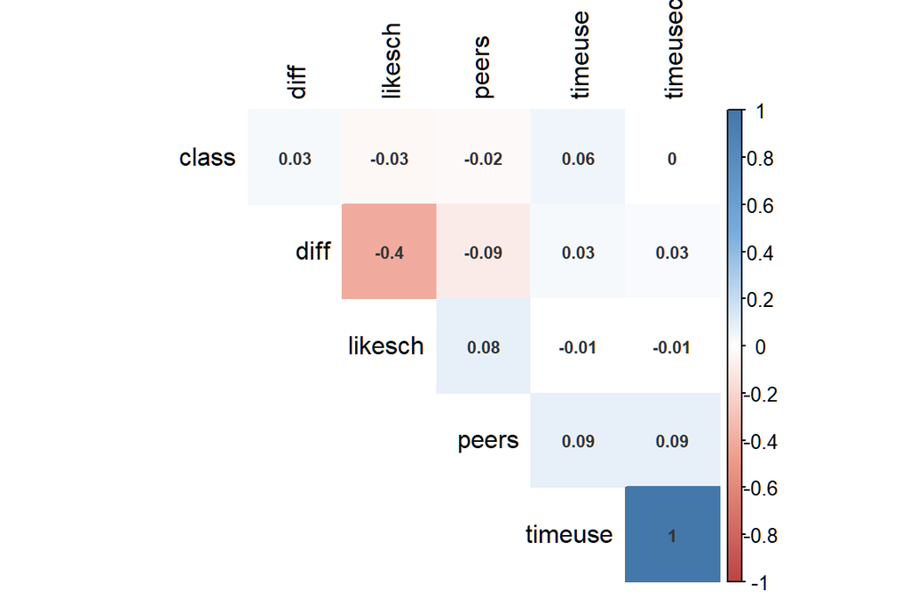

```r
library(corrplot)
external <- c('class', 'timeuse', 'timeusec', 'likesch', 'peers', 'diff')
# create dataset for analysis
dte <- dt[,..external ]
# Exclude cases with NA
dte <- dte[complete.cases(dte),]

# corr matrix
cor_matrix2 <- cor(dte)
# significance tests for corr matrix
res2 <- cor.mtest(dte, method="pearson", conf.level = .95)
# draw the corrplot with sig levels
col <- colorRampPalette(c("#BB4444", "#EE9988", "#FFFFFF", "#77AADD", "#4477AA"))
corrplot(cor_matrix2, method = "color", col = col(200),
         type = "upper", order = "hclust", number.cex = .7,
         addCoef.col = "grey20", # Add coefficient of correlation
         tl.col = "black", tl.srt = 90, # Text label color and rotation
         # Combine with significance, set visible sig level
         p.mat = res2$p, sig.level = 0.05, insig = "blank",
         # hide correlation coefficient on the principal diagonal
         diag = FALSE)
```

```r
# show the p-value
# res3 <- cor.test(dt$class, dt$diff,  method = "pearson")
```